# Notes for 16S `dada2` on HPC for AVCA-ElkLD project

### Plot error rates

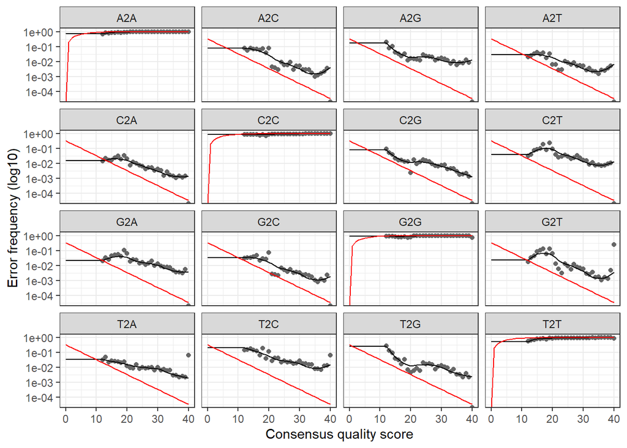

```r
# Plot error rates that are based on nucleotide transition probabilities and quality scores; observed scores (black) should match red lines (expected)
plotErrors(errF, nominalQ = TRUE)
```

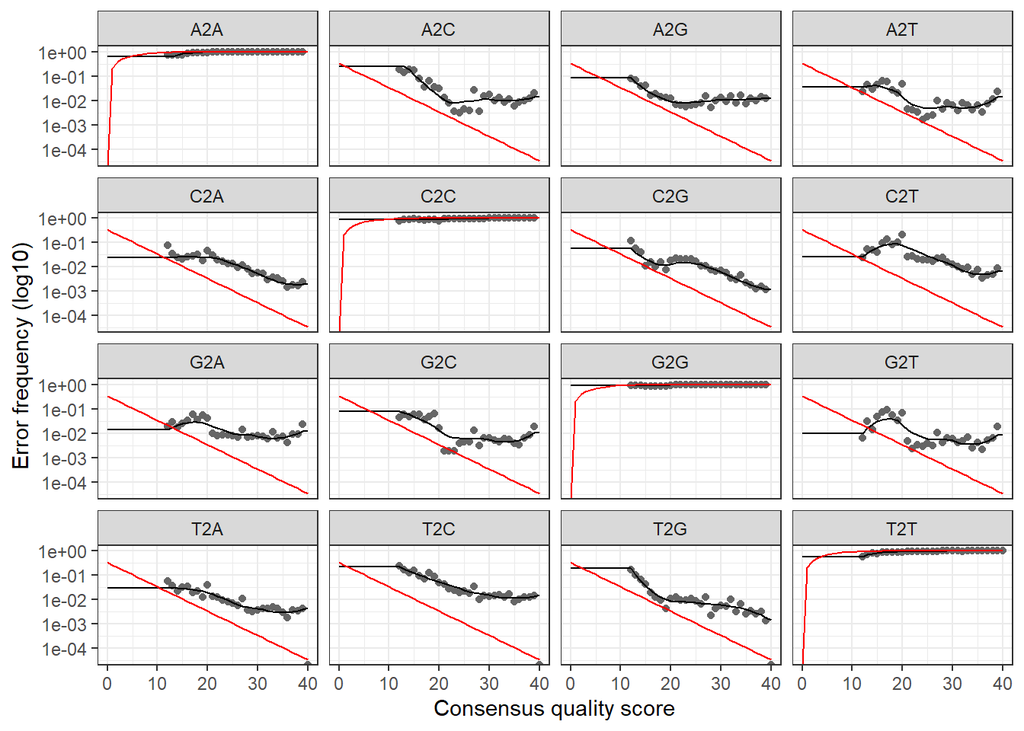

```r
plotErrors(errR, nominalQ = TRUE)
```

- These plots show the expected trends. For the A2A, C2C, G2G, and T2T plots the black lines (observed scores) match the red lines (expected scores) well.

### Save intermediate `.RData`

```r
save.image("16S_dada2_HPC1.RData")
```

- Save the first intermediate `.RData` file, because all the objects created are pretty small, but learning the error rates takes a while to run.

## Sample inference

### Remove replicate sequences

```r
# Reduce computation time by dereplicating identical sequences
derepFs <- derepFastq(filtFs, verbose = TRUE)
derepRs <- derepFastq(filtRs, verbose = TRUE)

# Name the derep-class objects by the sample names
names(derepFs) <- sample.names
names(derepRs) <- sample.names
```

- Takes about 2-3 seconds to process each sample on HPC with 94 cores and 5 gb/core.
- The output is something like “`Encountered 98936 unique sequences from 214422 total sequences read.`” for each sample.

### Save intermeditae `.RData`

```r
save(derepFs, file = "16S_dada2_HPC2.RData") # save separately because it is 10.1 GB
save(derepRs, file = "16S_dada2_HPC3.RData") # save separately because it is 13.3 GB
```

### Infer true sequence variants

```r
# Sample inference, this takes a while
dadaFs <- dada(derepFs, err = errF, multithread = TRUE)
dadaRs <- dada(derepRs, err = errR, multithread = TRUE)
```

- The first line of code took about 2 hours to run on HPC with 94 cores and 5 gb/core.
  - Most samples take 1-1.5 minutes to run (it varies based on how many reads and unique sequences the sample has).
  - The last sample, Sample 69, was of all the “unsigned” reads and was `Sample 69 - 1698261 reads in 1265578 unique sequences.`, and took about 40 minutes to run just this sample, which was way bigger than the rest (for comparison, Sample 1 was `Sample 1 - 214422 reads in 98936 unique sequences.`).
- The second line of code took about 1 hr and 40 minutes to run.
- The output is something like “`Sample 1 - 214422 reads in 98936 unique sequences.`” and goes through each sample.

### Inspect the `dada-class` object

```r
dadaFs[[1]]
```

```
## dada-class: object describing DADA2 denoising results
## 3088 sequence variants were inferred from 98936 input unique sequences.
## Key parameters: OMEGA_A = 1e-40, OMEGA_C = 1e-40, BAND_SIZE = 16
```

### Save intermediate `.RData`

```r
save(dadaFs, dadaRs, file = "16S_dada2_HPC4.RData")
```

## Merge pair-end reads

### Join forward and reverse reads

```r
# Join forward and reverse reads
mergers <- mergePairs(dadaFs, derepFs, dadaRs, derepRs, verbose = TRUE)
```

- It takes about 10-20 seconds to merge each sample on HPC with 94 cores at 5 gb/core.
- The output is something like “`131280 paired-reads (in 1993 unique pairings) successfully merged out of 202954 (in 28881 pairings) input.`”, and will go through each sample.
- The default is an overlap of 12 bp.

### Inspect merger

```r
# Inspect the merger data.frame from the first sample
head(mergers[[1]])
```

```
##                                                                                                                                                                                                                                    sequence
## 1 GCGAGCGTTGTCCGGAATTACTGGGCGTAAAGAGCTCGTAGGTGGTTTGTCGCGTTGTTC…
## 2 GCAAGCGTTGTCCGGAATTATTGGGCGTAAAGAGCTCGTAGGCGGCTTGTCACGTCGGGT…
## 3 GCTAGCGTTGTTCGGAATTACTGGGCGTAAAGCGCACGTAGGCGGCTTTGTAAGTTAGAG…
## 4 GCGAGCGTTAATCGGAATTACTGGGCGTAAAGTGTGCGCAGGCGGCTGAGCAAGTCGAGT…
## 5 GCAAGCGTTGTTCGGAATTACTGGGCGTAAAGGGCTCGTAGGCGGCCAACTAAGTCAGAC…
## 6 GCAAGCGTTATCCGGAATTATTGGGCGTAAAGAGCTCGTAGGCGGTTTGTCGCGTCTGCC…
##   abundance forward reverse nmatch nmismatch nindel prefer accept
## 1      1501       2       5     27         0      0      1   TRUE
## 2      1403       3       8     27         0      0      1   TRUE
## 3      1307       1       2     27         0      0      1   TRUE
## 4      1276       4       6     27         0      0      1   TRUE
## 5      1153       8       3     27         0      0      1   TRUE
## 6      1118       6      11     27         0      0      1   TRUE
```

### Save intermediate `.RData`

```r
save(dadaFs, dadaRs, mergers,
     file = "16S_dada2_HPC4.RData")
```

## Construct sequence table

### Make ASV table

```r
seqtab <- makeSequenceTable(mergers)
```

```r
dim(seqtab)
```

```
## [1]    69 32399
```

### Inspect ASV lengths

```r
# Inspect sequence lengths: Most amplicon sequence variants are 233bp
table(nchar(getSequences(seqtab)))
```

```
##
##   134   147   148   155   158   159   162   163   164   165   166   167   169
##     1     1     1     2     1     1     2     1     2     1     1     3     5
##   170   171   172   173   174   175   177   178   180   181   182   183   184
##     2     7     3     3     2     1     1    14     4     7    10     4     3
##   185   186   187   188   189   190   193   196   197   198   199   200   201
##     5     2     4     1     6     1     2     1     1     1     2    15    39
##   202   203   204   205   206   207   208   209   210   211   212   213   214
##     9    24    14    15    10    24    11     7     6     4     1     4     2
##   215   216   217   218   219   221   222   223   224   225   226   227   228
##     2     5    13    14     8     4     5     5     2    10    12    10    49
##   229   230   231   232   233   234   235   236   237   238   239   240   241
##    26    22    38   336 28028  2926   231   108    85    27    30    38    20
##   242   243   244   245   246   247   248
##     8     6     9     2     3     3    20
```

### Save intermediate `.RData`

```r
save(dadaFs, dadaRs, mergers, seqtab,
     file = "16S_dada2_HPC4.RData")
```

## Remove chimeras

```r
seqtab.nochim <- removeBimeraDenovo(seqtab,
                                    method = "consensus",
                                    multithread = TRUE,
                                    verbose = TRUE)
```

- Takes <1 min to run on HPC with 94 cores and 5 gb/core.
- The output in this example is: “`Identified 10325 bimeras out of 32399 input sequences.`”

```r
dim(seqtab.nochim)
```

```
## [1]    69 22074
```

```r
# How much of the dataset is left after chimera identification and removal?
sum(seqtab.nochim) / sum(seqtab) * 100
```

```
## [1] 93.95858
```

### Save intermediate `.RData`

```r
save(dadaFs, dadaRs, mergers, seqtab, seqtab.nochim,
     file = "16S_dada2_HPC4.RData")
```

## Track reads through pipeline

```r
# Create function
getN <- function(x) sum(getUniques(x))

# Create table
track <- cbind(out.df, sapply(dadaFs, getN), sapply(dadaRs, getN), sapply(mergers, getN), rowSums(seqtab.nochim))

# Rename columns
colnames(track) <- c("input",
                     "filtered",
                     "Retained %",
                     "denoisedF",
                     "denoisedR",
                     "merged",
                     "nonchim")
rownames(track) <- sample.names

# Total percent of dataset remaining
track$InputRetained <- track$nonchim / track$input * 100
head(track)
```

```
##                    input filtered Retained % denoisedF denoisedR merged nonchim
## avca-elkld_01_c21 240716   214422   89.07675    208380    208428 131280  126842
## avca-elkld_02_c21 198463   182287   91.84936    177256    178670 127037  121712
## avca-elkld_03_c21 239364   220719   92.21061    212898    215108 138262  131452
## avca-elkld_04_c21 275415   244654   88.83104    235940    238616 151112  143361
## avca-elkld_05_c21 225966   207029   91.61954    200003    201755 130856  125389
## avca-elkld_06_c21 243107   219935   90.46839    213219    213971 127617  121742
##                   InputRetained
## avca-elkld_01_c21      52.69363
## avca-elkld_02_c21      61.32730
## avca-elkld_03_c21      54.91720
## avca-elkld_04_c21      52.05272
## avca-elkld_05_c21      55.49021
## avca-elkld_06_c21      50.07754
```

```r
summary(track$InputRetained)
```

```
##    Min. 1st Qu.  Median    Mean 3rd Qu.    Max.
##   22.88   54.24   57.21   58.02   60.30   86.79
```

```r
track$FilteredRetained <- track$nonchim / track$filtered * 100
head(track)
```

```
##                    input filtered Retained % denoisedF denoisedR merged nonchim
## avca-elkld_01_c21 240716   214422   89.07675    208380    208428 131280  126842
## avca-elkld_02_c21 198463   182287   91.84936    177256    178670 127037  121712
## avca-elkld_03_c21 239364   220719   92.21061    212898    215108 138262  131452
## avca-elkld_04_c21 275415   244654   88.83104    235940    238616 151112  143361
## avca-elkld_05_c21 225966   207029   91.61954    200003    201755 130856  125389
## avca-elkld_06_c21 243107   219935   90.46839    213219    213971 127617  121742
##                   InputRetained FilteredRetained
## avca-elkld_01_c21      52.69363         59.15531
## avca-elkld_02_c21      61.32730         66.76944
## avca-elkld_03_c21      54.91720         59.55627
## avca-elkld_04_c21      52.05272         58.59745
## avca-elkld_05_c21      55.49021         60.56591
## avca-elkld_06_c21      50.07754         55.35363
```

```r
summary(track$FilteredRetained)
```

```
##    Min. 1st Qu.  Median    Mean 3rd Qu.    Max.
##   39.65   59.91   62.68   64.42   65.70   96.36
```

- Samples should have a majority of reads retained, so even if there is a large number of chimeras, they should relatively low in abundance. See [this tutorial FAQ](https://benjjneb.github.io/dada2/faq.html#why-are-so-many-of-my-reads-being-removed-as-chimeras) for more details.

```r
# Track soil samples only
track.soil <- track[1:62, ]
summary(track.soil$InputRetained)
```

```
##    Min. 1st Qu.  Median    Mean 3rd Qu.    Max.
##   50.08   54.04   56.94   56.86   59.24   66.07
```

```r
summary(track.soil$FilteredRetained)
```

```
##    Min. 1st Qu.  Median    Mean 3rd Qu.    Max.
##   55.35   59.85   62.51   62.62   65.20   71.83
```

- Examine soil samples only, not including blanks or the unsigned sample.

### Save intermediate `.RData`

```r
save(dadaFs, dadaRs, mergers, seqtab, seqtab.nochim, track, track.soil,
     file = "16S_dada2_HPC4.RData")
```

## Assign taxonomy

```r
taxa <- assignTaxonomy(seqtab.nochim,
                       "/home/u18/lossanna/silva_v138.1/silva_nr99_v138.1_train_set.fa.gz",
                       multithread = TRUE)

taxa <- addSpecies(taxa, "/home/u18/lossanna/silva_v138.1/silva_species_assignment_v138.1.fa.gz")
```

## Create ASV rep table

```r
# Create ASV rep table
ASV.rep <- data.frame(rep = colnames(seqtab.nochim))

ASV.rep[1:2, ]
```

```
## [1] "GCAAGCGTTATCCGGAATTATTGGGCGTAAAGAGCTCGTAGGCGGTTTGTCGCGTCTGCC…"
## [2] "GCTAGCGTTGTTCGGAATTACTGGGCGTAAAGCGCACGTAGGCGGCTTTGTAAGTTAGAG…"
```

```r
# Add ASV number column
ASV.rep$ASV <- c(1:ncol(seqtab.nochim))

ASV.rep[1:2, ]
```

```
##                                                                                                                                                                                                                                         rep
## 1 GCAAGCGTTATCCGGAATTATTGGGCGTAAAGAGCTCGTAGGCGGTTTGTCGCGTCTGCC…
## 2 GCTAGCGTTGTTCGGAATTACTGGGCGTAAAGCGCACGTAGGCGGCTTTGTAAGTTAGAG…
##   ASV
## 1   1
## 2   2
```

```r
# Add ASV_ to column
ASV.rep$ASV <- paste("ASV_", ASV.rep$ASV, sep = "")

ASV.rep[1:2, ]
```

```
##                                                                                                                                                                                                                                         rep
## 1 GCAAGCGTTATCCGGAATTATTGGGCGTAAAGAGCTCGTAGGCGGTTTGTCGCGTCTGCC…
## 2 GCTAGCGTTGTTCGGAATTACTGGGCGTAAAGCGCACGTAGGCGGCTTTGTAAGTTAGAG…
##     ASV
## 1 ASV_1
## 2 ASV_2
```

## Add ASV names to other tables

```r
# Change the representative sequence in ASV and taxonomy tables to ASV ID
colnames(seqtab.nochim) <- ASV.rep$ASV
rownames(taxa) <- ASV.rep$ASV

seqtab.nochim[1:4, 1:5]
```

```
##                   ASV_1 ASV_2 ASV_3 ASV_4 ASV_5
## avca-elkld_01_c21  1118  1307   377   116   293
## avca-elkld_02_c21  3492  1470  1297  1066   635
## avca-elkld_03_c21  3027  1165   612   551   252
## avca-elkld_04_c21  7502  1209  1393   516   510
```

```r
head(taxa)
```

```
##       Kingdom    Phylum             Class                 Order
## ASV_1 "Bacteria" "Actinobacteriota" "Actinobacteria"      "Micrococcales"
## ASV_2 "Bacteria" "Proteobacteria"   "Alphaproteobacteria" "Sphingomonadales"
## ASV_3 "Bacteria" "Actinobacteriota" "Actinobacteria"      "Frankiales"
## ASV_4 "Bacteria" "Proteobacteria"   "Gammaproteobacteria" "Burkholderiales"
## ASV_5 "Bacteria" "Proteobacteria"   "Gammaproteobacteria" "Burkholderiales"
## ASV_6 "Bacteria" "Acidobacteriota"  "Blastocatellia"      "Pyrinomonadales"
##       Family                Genus               Species
## ASV_1 "Micrococcaceae"      "Pseudarthrobacter" NA
## ASV_2 "Sphingomonadaceae"   "Sphingomonas"      NA
## ASV_3 "Geodermatophilaceae" "Blastococcus"      NA
## ASV_4 "Oxalobacteraceae"    "Massilia"          NA
## ASV_5 "Oxalobacteraceae"    "Massilia"          NA
## ASV_6 "Pyrinomonadaceae"    "RB41"              NA
```

## Save tables as `.txt` files

```r
# Save ASV table, taxonomy table and ASV rep
write.table(taxa, "16S_taxa_table.txt", sep = "\t", quote = FALSE)
write.table(seqtab.nochim, "16S_asv_table.txt", sep = "\t", quote = FALSE)
write.table(track, "16S_sequence_pipeline_stats.txt", sep = "\t", quote = FALSE)
write.table(ASV.rep,"16S_ASV_rep.txt",sep = "\t", quote = FALSE)
```

### Save intermediate `.RData`

```r
save(dadaFs, dadaRs, mergers, seqtab, seqtab.nochim, track, track.soil, taxa, ASV.rep,
     file = "16S_dada2_HPC4.RData")

# Remove large objects and save workspace
rm(derepFs, derepRs)
save.image("16S_dada2_HPC_small.RData")
```

- The only files that are very large and cause the system to crash are the `derepFs` and `derepRs` objects. Remove those, and all the objects can be saved in a single file.